# BRCA clock stability and QC

Pan-cancer aging pipeline

October 24, 2026

## Cohort context

This report summarizes **QC, cohort shift, and stability** checks for a single pair:

- **TCGA tumor cohort:** BRCA
- **GTEx tissue cohort:** BREAST
- **Feature set:** PC
- **Output directory:** results/derived/GTEx/BRCA__BREAST

# A) Cohort shift and QC

**Goal:** Identify gross **batch effects / cohort shifts** between GTEx normals, TCGA adjacent normals (if present), and TCGA tumors using ssGSEA pathway space.

## Age coverage

**Goal:** Confirm basic age coverage and sample sizes; large age-range differences can affect calibration and deviation estimates.

| cohort | n | min | med | max |
| --- | --- | --- | --- | --- |
| GTEx | 482 | 21 | 54 | 70 |
| TCGA-PT | 1120 | 26 | 58 | 90 |
| TCGA-AN | 112 | 30 | 56 | 90 |

## PCA in pathway space

**Goal:** Visualize the largest axes of variation to quickly surface issues like tissue mismatch, strong batch effects, or tumors separating along a dominant technical axis.

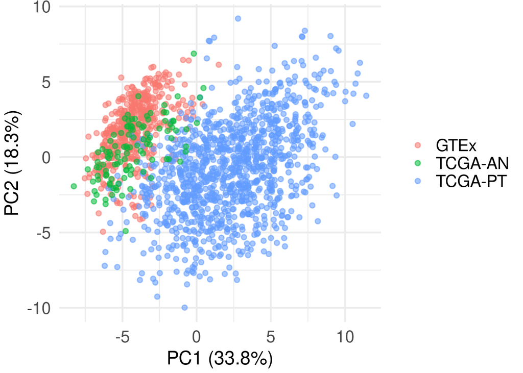

## PC-space distances and dispersion

**Goal:** Quantify separation between cohorts (centroid distances) and internal heterogeneity (mean distance to centroid), complementing the PCA scatter.

| from | to | dist | from_disp | to_disp |
| --- | --- | --- | --- | --- |
| GTEx | TCGA-AN | 3.93 | 4.43 | 4.38 |
| GTEx | TCGA-PT | 7.26 | 4.43 | 5.81 |
| TCGA-AN | TCGA-PT | 7.12 | 4.38 | 5.81 |

## Pathway-level cohort shifts

**Goal:** Identify pathways with the largest cohort-level shifts (Cohen’s d), which often explain cohort separation in PCA.

| pathway | d_pt_vs_gtex | d_nat_vs_gtex | d_pt_vs_nat |
| --- | --- | --- | --- |
| Myogenesis | -3.34 | -1.05 | -2.2 |
| E2f Targets | 2.6 | 1.16 | 1.96 |
| G2m Checkpoint | 2.6 | 1.43 | 1.85 |
| Mtorc1 Signaling | 2.31 | 1.04 | 1.43 |
| Glycolysis | 2.17 | 1.19 | 1.21 |
| Hypoxia | -2.12 | -0.664 | -1.54 |
| Myc Targets V1 | 2.03 | 0.554 | 1.53 |
| Spermatogenesis | 1.93 | 0.845 | 1.31 |
| Unfolded Protein Response | 1.91 | 0.19 | 1.79 |
| Xenobiotic Metabolism | -1.89 | -0.182 | -1.63 |

[output cut: 15 more lines]

# B) Contribution and clock stability

**Goal:** Check that the reported top contributing pathways are **not brittle** to (i) tuning choices, and (ii) sampling variation in the tumor cohort.

## Baseline contribution source

**Goal:** Make the “baseline contribution matrix” explicit, including which source was used and whether the $\sum_k \phi_{ik} = deviation_i$ invariant holds.

| quantity | value |
| --- | --- |
| baseline phi source | clockshap_objects |
| PT samples (before alignment) | 1117 |
| PT samples (after alignment) | 1117 |
| max \|rowSums(phi) - deviation\| | 2.13163e-14 |

### Baseline top contributors

**Goal:** Provide an interpretable “headline” ranking of pathways driving tumor deviation (mean |φ| across tumors).

| feature | mean_phi | mean_abs_phi | sd_phi |
| --- | --- | --- | --- |
| G2m Checkpoint | -7.42 | 7.42 | 3.36 |
| Glycolysis | -6.31 | 6.39 | 3.11 |
| Myogenesis | -4.77 | 4.78 | 1.54 |
| P53 Pathway | -2.96 | 3.76 | 3.79 |
| Wnt Beta Catenin Signaling | 2.44 | 2.64 | 1.83 |
| Unfolded Protein Response | 2.34 | 2.38 | 1.29 |
| Tnfa Signaling Via Nfkb | -1.98 | 2.1 | 1.44 |
| Il2 Stat5 Signaling | -1.44 | 1.98 | 1.94 |
| Uv Response Up | -0.378 | 1.36 | 1.78 |
| Pancreas Beta Cells | 0.069 | 1.18 | 1.61 |

[output cut: 15 more lines]

## Permuted-age null

**Goal:** Refit the same clock form on GTEx after *permuting ages* (destroying age signal), then compute the PT deviation under the permuted model.  
If the observed PT deviation is extreme relative to this null, it supports the deviation reflecting a real aging signal rather than purely model structure or cohort shift.

| metric | observed | null_mean | null_sd | empirical_p |
| --- | --- | --- | --- | --- |
| PT mean deviation | -22.9 | -0.0599 | 4.41 | 0.000999 |
| PT median deviation | -23.1 | -0.0612 | 4.35 | 0.000999 |
| PT–AN mean deviation (delta) | -17.6 | 0.0175 | 3.78 | 0.000999 |

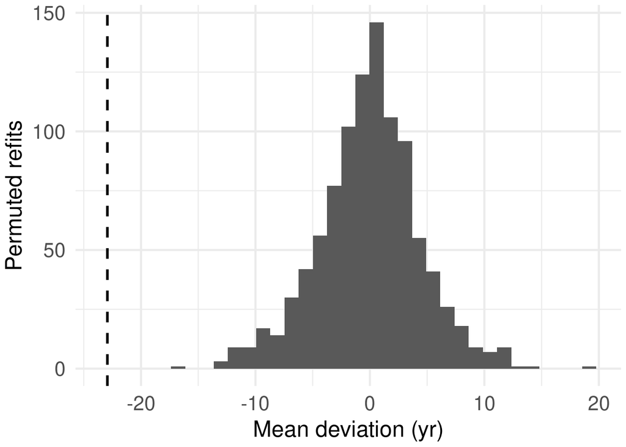

## Hyperparameter neighborhood stability

**Goal:** Refit clocks in a small neighborhood around the tuned $(\\alpha, \\lambda)$ and test whether the **rank and sign** of top contributors are stable.

| n_models | spearman_meanphi_pairwise_med | topk_jaccard_vs_baseline_med | topk_jaccard_vs_baseline_min | pt_subsample_n |
| --- | --- | --- | --- | --- |
| 9 | 0.842 | 0.579 | 0.364 | 500 |

| feature | baseline_mean_abs_phi | median_rank | iqr_rank | sign_stability | topk_freq | median_mean_phi |
| --- | --- | --- | --- | --- | --- | --- |
| G2m Checkpoint | 7.42 | 1 | 0 | 1 | 1 | -7.25 |
| Glycolysis | 6.39 | 2 | 1 | 1 | 1 | -6.23 |
| Myogenesis | 4.78 | 3 | 0 | 1 | 1 | -4.79 |
| P53 Pathway | 3.76 | 4 | 1 | 1 | 1 | -2.95 |
| Unfolded Protein Response | 2.38 | 6 | 2 | 0.889 | 0.889 | 2.32 |
| Wnt Beta Catenin Signaling | 2.64 | 6 | 1 | 0.889 | 0.889 | 2.5 |
| Tnfa Signaling Via Nfkb | 2.1 | 7 | 3 | 1 | 1 | -1.9 |
| Il2 Stat5 Signaling | 1.98 | 8 | 2 | 1 | 1 | -1.36 |
| Hypoxia | 1.14 | 9 | 2 | 0.889 | 0.778 | -1.04 |
| Coagulation | 0.673 | 11 | 8 | 1 | 0.556 | -0.362 |

[output cut: 15 more lines]

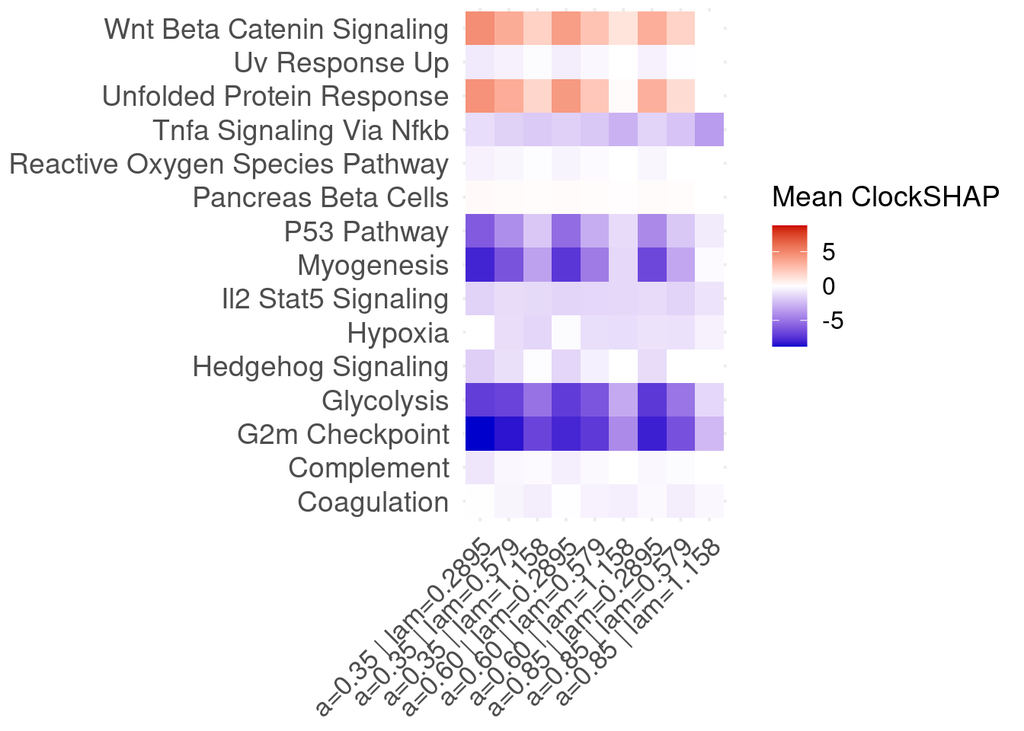

## Tumor bootstrap stability (not used in the manuscript)

**Goal:** Resample tumor samples with replacement and recompute mean contributions. This tests whether the top contributors are stable to sampling variation in the tumor cohort. The PDF save for this plot is disabled.

| ran_n_boot | spearman_pairwise_med | topk_jaccard_vs_baseline_med | topk_jaccard_vs_baseline_min |
| --- | --- | --- | --- |
| 1000 | 1 | 1 | 0.765 |

| feature | baseline_mean_abs_phi | sign_stability | topk_freq | median_mean_phi |
| --- | --- | --- | --- | --- |
| G2m Checkpoint | 7.42 | 1 | 1 | -7.41 |
| Glycolysis | 6.39 | 1 | 1 | -6.31 |
| Myogenesis | 4.78 | 1 | 1 | -4.77 |
| P53 Pathway | 3.76 | 1 | 1 | -2.96 |
| Wnt Beta Catenin Signaling | 2.64 | 1 | 1 | 2.43 |
| Unfolded Protein Response | 2.38 | 1 | 1 | 2.33 |
| Tnfa Signaling Via Nfkb | 2.1 | 1 | 1 | -1.98 |
| Il2 Stat5 Signaling | 1.98 | 1 | 1 | -1.44 |
| Uv Response Up | 1.36 | 1 | 1 | -0.377 |
| Pancreas Beta Cells | 1.18 | 0.927 | 0.058 | 0.07 |

[output cut: 15 more lines]

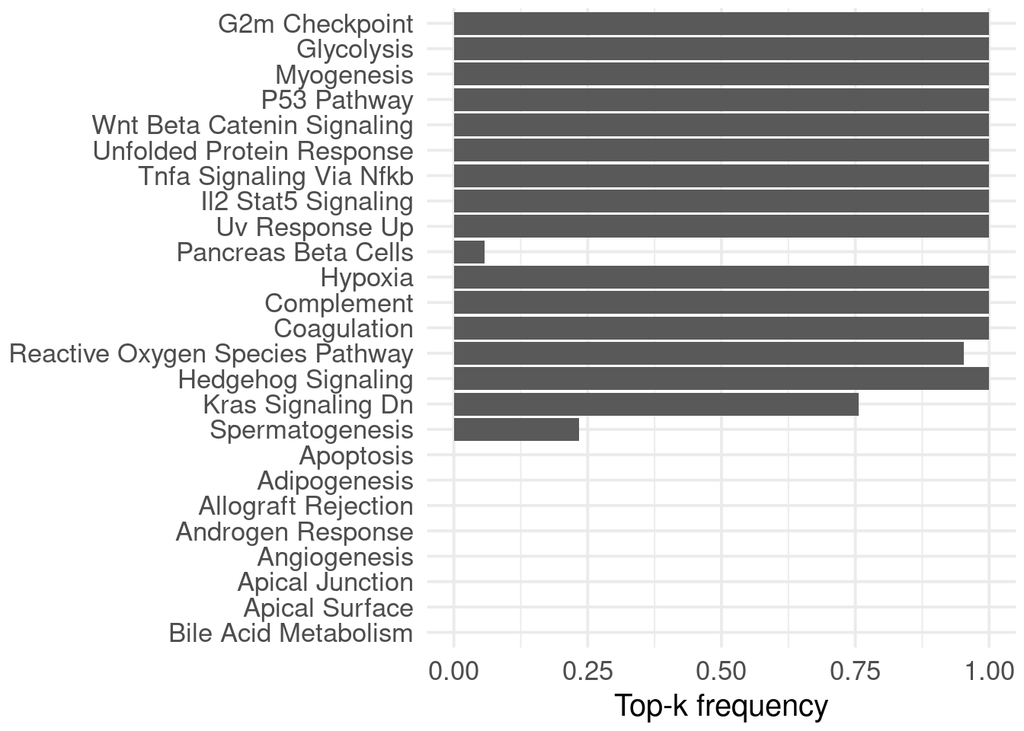

## GTEx refit stability

**Goal:** Resample GTEx samples (with replacement), refit the clock at tuned hyperparameters, and check whether the **same pathways** and **directions** are consistently recovered.

| ran_n_boot | spearman_pairwise_med_topk | topk_jaccard_vs_baseline_med | topk_jaccard_vs_baseline_min |
| --- | --- | --- | --- |
| 1000 | 0.788 | 0.579 | 0.304 |

| feature | baseline_coef | baseline_sign | selection_freq | sign_stability_if_selected | median_coef | iqr_coef |
| --- | --- | --- | --- | --- | --- | --- |
| P53 Pathway | 0.0107 | 1 | 0.999 | 1 | 0.0102 | 0.00465 |
| Glycolysis | -0.0106 | -1 | 0.973 | 1 | -0.0085 | 0.00543 |
| Uv Response Up | -0.00592 | -1 | 0.853 | 1 | -0.0045 | 0.00599 |
| Unfolded Protein Response | 0.00458 | 1 | 0.891 | 1 | 0.00388 | 0.00447 |
| Wnt Beta Catenin Signaling | -0.00436 | -1 | 0.944 | 1 | -0.00478 | 0.00388 |
| Il2 Stat5 Signaling | 0.00418 | 1 | 0.699 | 1 | 0.00233 | 0.00502 |
| G2m Checkpoint | -0.00399 | -1 | 0.816 | 1 | -0.00334 | 0.00479 |
| Myogenesis | 0.00359 | 1 | 0.909 | 1 | 0.0033 | 0.00302 |
| Pancreas Beta Cells | -0.00348 | -1 | 0.914 | 1 | -0.00331 | 0.00348 |
| Complement | 0.002 | 1 | 0.566 | 1 | 0.000418 | 0.00232 |

[output cut: 15 more lines]

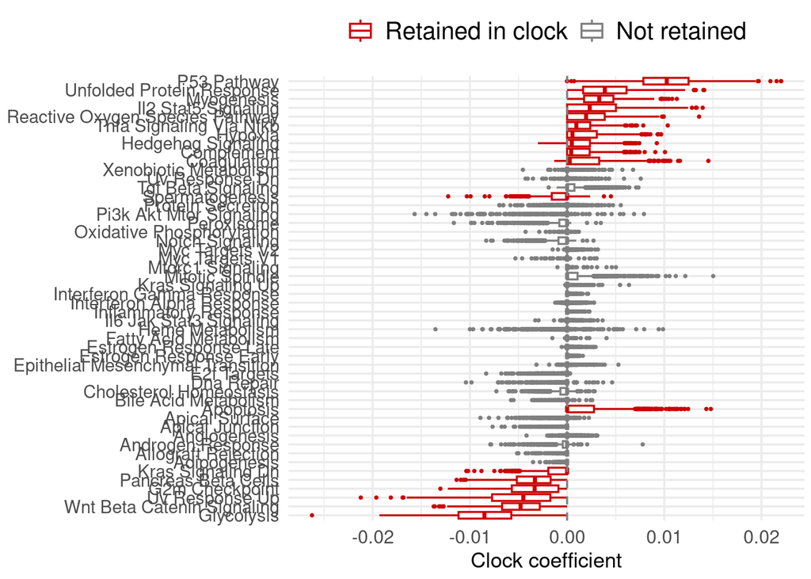

# C) Coupling stability summary (not used in the manuscript)

**Goal:** If a coupling step produced coupling bootstrap descriptors, import them here for a single “stability dashboard” view (no recomputation in this report). The coupling step is not part of the manuscript or this repository, so this section is normally skipped.

Imported coupling bootstrap summary from the coupling step outputs.

| analysis_id | bootstrap_mode | n_boot | ci_level | cancellation_flag | gamma_gtex_raw_med | gamma_pt_raw_med | delta_gamma_med | gamma_pt_cal_med |
| --- | --- | --- | --- | --- | --- | --- | --- | --- |
| BRCA__BREAST | pt_and_gtex | 1000 | 0.95 | High cancellation | 0.178 | 0.0111 | -0.168 | 0.832 |